# SWNS/BoF Herring MSE MP Testing Results

#### Tradeoff Plots

Plots show the performance for median across OMs. Error bars = performance for the most pessimistic and optimistic OMs

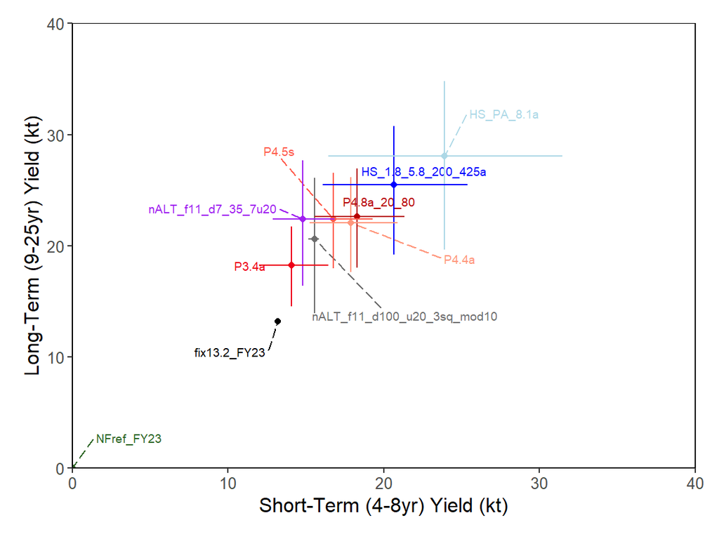

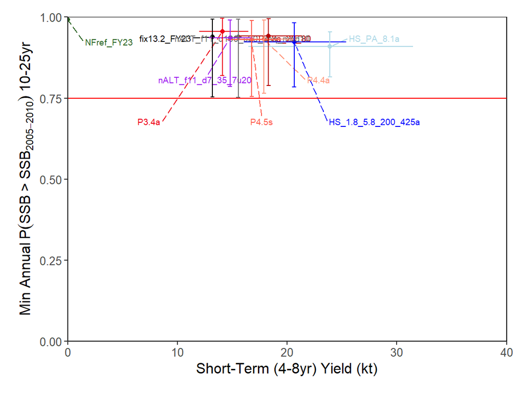

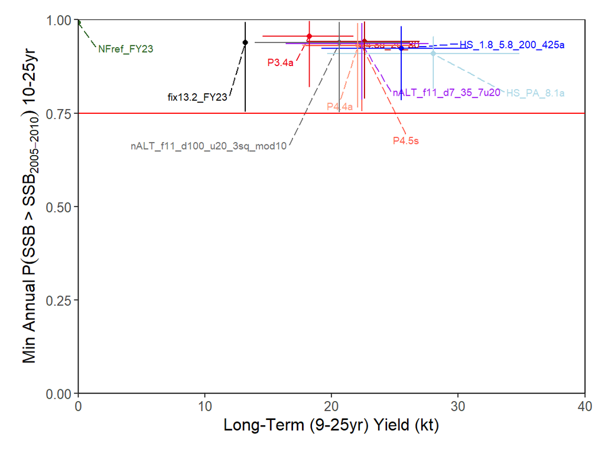

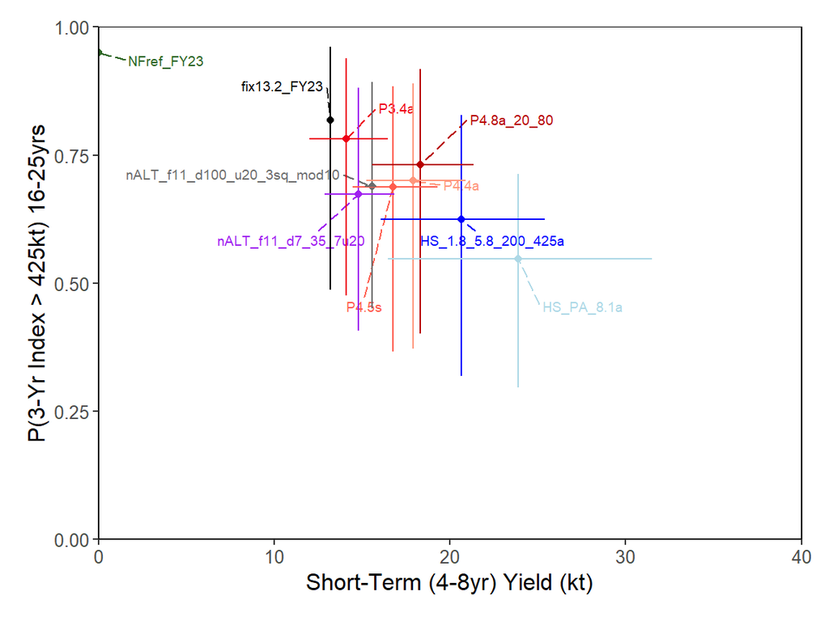

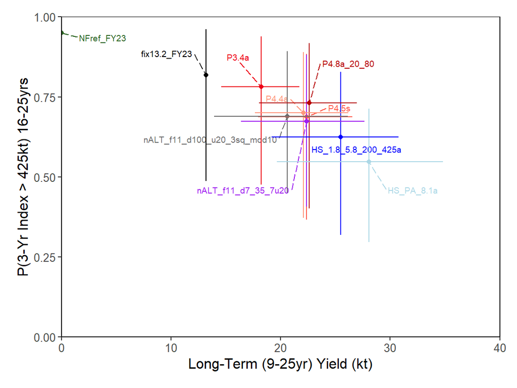

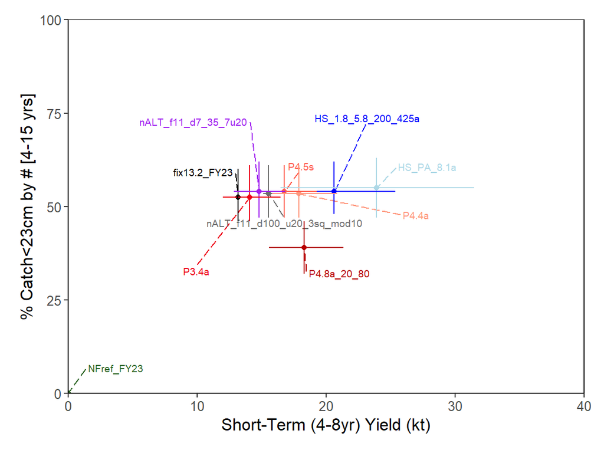

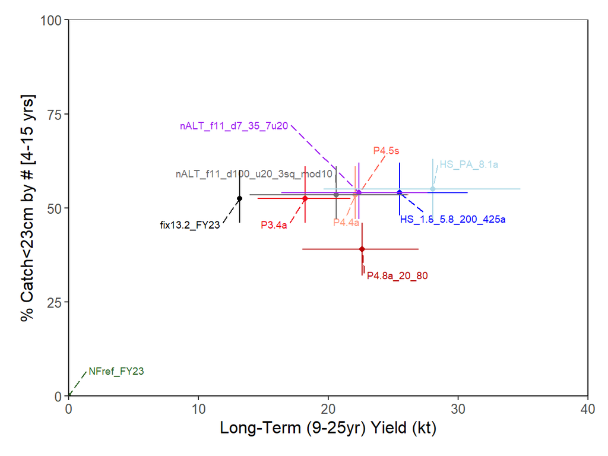

#### Table of Results by MP

Median value or probability for the most pessimistic OM, median performing OM, and most optimistic OM for each metric  
minP(SSB>SSB0510) = minimum annual probability of model estimated SSB being above the mean model estimated SSB from 2005-2010 in projection years 10-15

P(>425) = Probability 3-yr moving average index > 425kt

P(>500) = Probability 3-yr moving average index > 500kt

STY = Short term (4-8 year) yield (kt)

LTY = Long term (9-25 year) yield (kt)

AAVY = average annual variability in yield (%)

|  | MP | minP(SSB>SSB0510)_yr10-15_l | minP(SSB>SSB0510)_yr10-15 | minP(SSB>SSB0510)_yr10-15_u | P>425_yr16-25_l | P>425_yr16-25 | P>425_yr16-25 | P>500_yr16-25_l | P>500_yr16-25 | P>500_yr16-25 | STY_l | STY | STY_u | LTY_l | LTY | LTY_u | AAVY_l | AAVY | AAVY_u | %<23cm_l | %<23cm | %<23cm_u |
| --- | --- | --- | --- | --- | --- | --- | --- | --- | --- | --- | --- | --- | --- | --- | --- | --- | --- | --- | --- | --- | --- | --- |
| 1 | HS_1.8_5.8_200_425a | 0.785 | 0.923 | 0.982 | 0.318 | 0.624 | 0.827 | 0.14 | 0.387 | 0.627 | 16 | 21 | 25 | 19 | 25 | 31 | 29 | 45 | 56 | 48 | 54 | 62 |
| 2 | HS_PA_8.1a | 0.815 | 0.909 | 0.953 | 0.296 | 0.548 | 0.713 | 0.119 | 0.301 | 0.48 | 16 | 24 | 31 | 20 | 28 | 35 | 42 | 84 | 560 | 47 | 55 | 63 |
| 3 | NFref_FY23 | 0.932 | 0.992 | 1 | 0.793 | 0.95 | 0.993 | 0.595 | 0.869 | 0.976 | 0 | 0 | 0 | 0 | 0 | 0 | 0 | 0 | 0 | 0 | 0 | 0 |
| 4 | P3.4a | 0.819 | 0.956 | 0.996 | 0.475 | 0.782 | 0.939 | 0.255 | 0.576 | 0.839 | 12 | 14 | 16 | 15 | 18 | 22 | 19 | 27 | 35 | 46 | 52 | 61 |
| 5 | P4.4a | 0.765 | 0.932 | 0.991 | 0.373 | 0.7 | 0.89 | 0.181 | 0.48 | 0.748 | 15 | 18 | 21 | 18 | 22 | 26 | 19 | 27 | 35 | 47 | 54 | 61 |
| 6 | P4.5s | 0.755 | 0.93 | 0.989 | 0.366 | 0.688 | 0.884 | 0.179 | 0.47 | 0.741 | 14 | 17 | 19 | 18 | 22 | 27 | 7.1 | 11 | 14 | 47 | 54 | 61 |
| 7 | P4.8a_20_80 | 0.789 | 0.942 | 0.995 | 0.402 | 0.731 | 0.918 | 0.199 | 0.515 | 0.799 | 16 | 18 | 21 | 18 | 23 | 27 | 20 | 27 | 35 | 32 | 39 | 46 |
| 8 | fix13.2_FY23 | 0.754 | 0.939 | 0.993 | 0.487 | 0.818 | 0.962 | 0.288 | 0.646 | 0.89 | 13 | 13 | 13 | 13 | 13 | 13 | 0 | 0 | 0 | 46 | 52 | 60 |
| 9 | nALT_f11_d100_u20_3sq_mod10 | 0.753 | 0.939 | 0.994 | 0.451 | 0.689 | 0.892 | 0.245 | 0.472 | 0.754 | 15 | 16 | 16 | 14 | 21 | 26 | 14 | 17 | 22 | 47 | 54 | 61 |
| 10 | nALT_f11_d7_35_7u20 | 0.786 | 0.936 | 0.99 | 0.407 | 0.674 | 0.882 | 0.209 | 0.453 | 0.729 | 13 | 15 | 17 | 16 | 22 | 28 | 12 | 14 | 22 | 47 | 54 | 62 |

|  | MP | y7 | y8 | y9 | y10 | y11 | y12 | y13 | y14 | y15 | y16 | y17 | y18 | y19 | y20 | y21 | y22 | y23 | y24 | y25 |
| --- | --- | --- | --- | --- | --- | --- | --- | --- | --- | --- | --- | --- | --- | --- | --- | --- | --- | --- | --- | --- |
| 1 | HS_1.8_5.8_200_425a | 0.713 | 0.738 | 0.766 | 0.79 | 0.785 | 0.807 | 0.829 | 0.83 | 0.842 | 0.825 | 0.82 | 0.825 | 0.809 | 0.793 | 0.786 | 0.792 | 0.782 | 0.801 | 0.784 |
| 2 | HS_PA_8.1a | 0.764 | 0.771 | 0.803 | 0.815 | 0.82 | 0.841 | 0.835 | 0.834 | 0.844 | 0.847 | 0.827 | 0.824 | 0.812 | 0.791 | 0.794 | 0.79 | 0.793 | 0.803 | 0.787 |
| 3 | NFref_FY23 | 0.82 | 0.87 | 0.9 | 0.932 | 0.951 | 0.962 | 0.972 | 0.976 | 0.978 | 0.98 | 0.983 | 0.986 | 0.988 | 0.988 | 0.984 | 0.986 | 0.981 | 0.984 | 0.981 |
| 4 | P3.4a | 0.717 | 0.759 | 0.791 | 0.819 | 0.834 | 0.852 | 0.868 | 0.883 | 0.893 | 0.895 | 0.892 | 0.899 | 0.885 | 0.885 | 0.88 | 0.872 | 0.875 | 0.885 | 0.884 |
| 5 | P4.4a | 0.68 | 0.717 | 0.742 | 0.765 | 0.78 | 0.803 | 0.812 | 0.823 | 0.845 | 0.827 | 0.831 | 0.834 | 0.826 | 0.817 | 0.8 | 0.809 | 0.805 | 0.81 | 0.795 |
| 6 | P4.5s | 0.681 | 0.713 | 0.745 | 0.755 | 0.774 | 0.8 | 0.81 | 0.818 | 0.829 | 0.818 | 0.827 | 0.827 | 0.81 | 0.809 | 0.786 | 0.788 | 0.792 | 0.799 | 0.781 |
| 7 | P4.8a_20_80 | 0.708 | 0.737 | 0.767 | 0.789 | 0.804 | 0.823 | 0.836 | 0.843 | 0.862 | 0.855 | 0.847 | 0.849 | 0.843 | 0.84 | 0.829 | 0.83 | 0.833 | 0.836 | 0.828 |
| 8 | fix13.2_FY23 | 0.664 | 0.699 | 0.727 | 0.754 | 0.77 | 0.802 | 0.818 | 0.845 | 0.845 | 0.855 | 0.853 | 0.871 | 0.856 | 0.858 | 0.854 | 0.839 | 0.85 | 0.86 | 0.861 |
| 9 | nALT_f11_d100_u20_3sq | 0.558 | 0.625 | 0.703 | 0.743 | 0.778 | 0.819 | 0.85 | 0.863 | 0.886 | 0.886 | 0.89 | 0.889 | 0.881 | 0.873 | 0.872 | 0.858 | 0.862 | 0.87 | 0.872 |
| 10 | nALT_f11_d100_u20_3sq_mod10 | 0.558 | 0.625 | 0.699 | 0.753 | 0.788 | 0.831 | 0.853 | 0.873 | 0.889 | 0.89 | 0.89 | 0.892 | 0.881 | 0.87 | 0.871 | 0.857 | 0.859 | 0.869 | 0.869 |

[output cut: 2 more lines]

## About

This report was generated on: 2024-03-22 14:36:03.747097  
SAMtool R package version 1.6.3  
MSEtool R package version 3.7.0  
R version 4.3.1 (2023-06-16 ucrt)